# Estadística Multivariada. Examen Parcial 1

Felipe Gerard

5 de marzo de 2015

# 1. Aprender Estructura

Importamos las librerias y cargamos los datos. Luego separamos en muestra de entrenamiento y prueba:

```r
setwd('/Users/Felipe/Dropbox/Maestria/Estadistica_Multivariada/parciales/')
load("mkt.Rdata")
library(Hmisc)
library(arm)
library(glmnet)
library(bnlearn)
library(gRain)
library(ggplot2)
library(tidyr)
library(dplyr)
library(Rgraphviz)
library(pROC)

set.seed(18937)
mkt_train <- sample_n(mkt, 30000)
mkt_test <- anti_join(mkt, mkt_train)
dim(mkt)
```

```
## [1] 40690    16
```

```r
numericas <- c('age','balance','duration','campaign','previous')
mkt_train[numericas] <- data.frame(lapply(mkt_train[numericas], as.numeric))
head(mkt_train)
```

```
##       age         job marital education default balance housing loan
## 8975   53     retired married secondary      no    1630      no   no
## 12200  36      admin. married  tertiary      no     425      no   no
## 15946  34  technician married secondary      no       1      no   no
## 26005  30 blue-collar married secondary      no     913     yes  yes
## 7639   28      admin. married secondary      no    7707     yes   no
## 15730  32  technician married secondary      no    -796     yes  yes
##        contact month duration campaign previous poutcome  y    id
## 8975   unknown   jun      160        1        0  unknown no  8975
## 12200  unknown   jun       11        4        0  unknown no 12200
## 15946 cellular   jul      344        3        0  unknown no 15946
## 26005 cellular   nov      433        2        0  unknown no 26005
## 7639   unknown   may       68        2        0  unknown no  7639
## 15730 cellular   jul       80        3        0  unknown no 15730
```

Antes de empezar a construir los modelos, hay que preparar los datos. Hay algunas variables numéricas que debemos discretizar. A continuación mostramos los histogramas de las variables numéricas (normalizadas a sus respectivos máximos) para darnos una idea de lo dispersas que están:

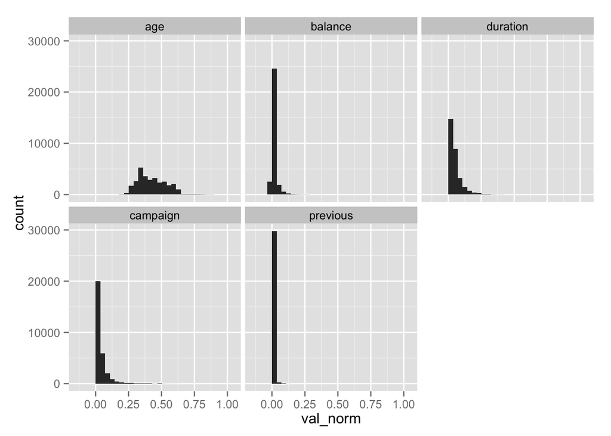

```r
aux <- gather(mkt_train, var, val, age, balance, duration, campaign, previous) %>%
  group_by(var) %>%
  mutate(val_norm = val/max(val))
qplot(val_norm, data=aux, geom='bar') + facet_wrap(~var)
```

Como vemos, todas las variables menos `previous` tienen un nivel suficiente de dispersión para ser discretizadas. Ignoraremos previous por el momento porque no aporta mucha información. Discretizamos las variables con la función `cut2` del paquete `Hmisc`, que lo que hace es intenta partir en grupos con la misma población. Decidimos dicho número para cada variable con criterio experto según su dispersión:

```r
mkt_train$age_disc <- cut2(mkt_train$age, g = 4)
mkt_train$balance_disc <- cut2(mkt_train$balance, g = 5)
mkt_train$duration_disc <- cut2(mkt_train$duration, g = 5)
mkt_train$campaign_disc <- cut2(mkt_train$campaign, g = 4)

# Quitamos las numericas para el ajuste y convertimos a factores
cats <- sapply(mkt_train, function(x) !is.numeric(x))
mkt_train_disc <- data.frame(mkt_train[cats], stringsAsFactors = T)
```

Ahora bien, para discretizar la base de prueba necesitamos usar los mismos factores que en entrenamiento. Para ello utilizaremos la función `factoriza`, que escribimos específicamente para este problema:

```r
factoriza <- function(v, niveles, silent = T){
  require(dplyr)
  niveles <- niveles
  regex <- gregexpr('-?[0-9]+', niveles)
  niveles_df <- data.frame(t(sapply(1:length(regex), function(i){
    m <- substr(niveles[i], regex[[i]][1], regex[[i]][1]+attr(regex[[i]], 'match.length')[1]-1)
    if(length(regex[[i]]) == 2){
      M <- substr(niveles[i], regex[[i]][2], regex[[i]][2]+attr(regex[[i]], 'match.length')[2]-1)
    }else{
      M <- m
    }
    c(m,M)
  })), stringsAsFactors = F)
  niveles_df <- cbind(niveles_df, niveles)
  names(niveles_df) <- c('min','max','nivel')
  niveles_df$min <- as.numeric(niveles_df$min)
  niveles_df$max <- as.numeric(niveles_df$max)
  #print(regex)
  if(!silent) print(niveles_df, length(v))
  sapply(v, function(i){
    niveles_df %>% filter(ifelse(min == max, min == i, min <= i & i < max)) %>% dplyr::select(nivel)
  }) %>% unlist %>% factor(levels = niveles)
}

mkt_test$age_disc <- factoriza(mkt_test$age, levels(mkt_train$age_disc))
mkt_test$balance_disc <- factoriza(mkt_test$balance, levels(mkt_train$balance_disc))
mkt_test$duration_disc <- factoriza(mkt_test$duration, levels(mkt_train$duration_disc))
mkt_test$campaign_disc <- factoriza(mkt_test$campaign, levels(mkt_train$campaign_disc))
```

Ahora sí podemos aprender estructura. En esta primera versión hacemos un modelo con AIC y uno con BIC, utilizando como *blacklist* únicamente los arcos salientes de `y`:

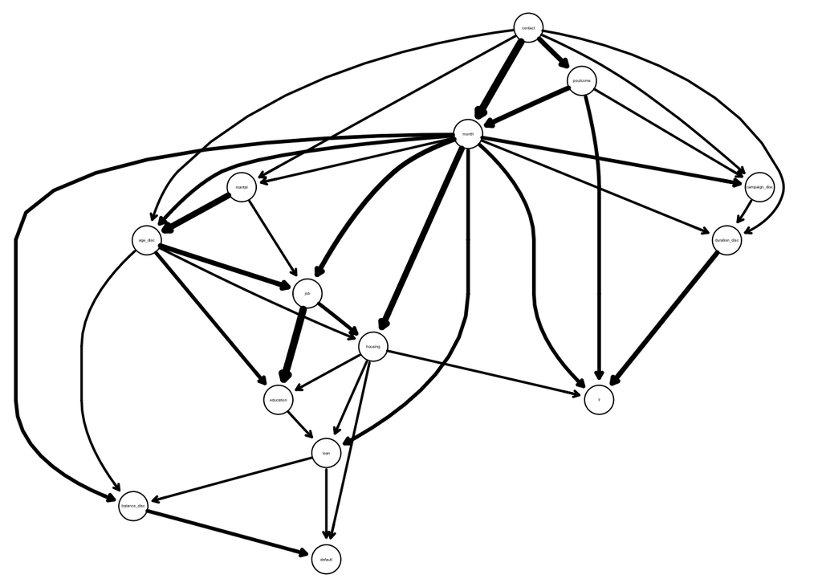

```r
blk.1 <- expand.grid(from=c('y'), to=names(mkt_train_disc))
net.aic.1 <- hc(mkt_train_disc,
              score = 'aic', blacklist = blk.1)
net.bic.1 <- hc(mkt_train_disc,
              score = 'bic', blacklist = blk.1)
strength.aic.1 <- arc.strength(net.aic.1, mkt_train_disc)
strength.bic.1 <- arc.strength(net.bic.1, mkt_train_disc)
strength.plot(net.aic.1, strength = strength.aic.1)
```

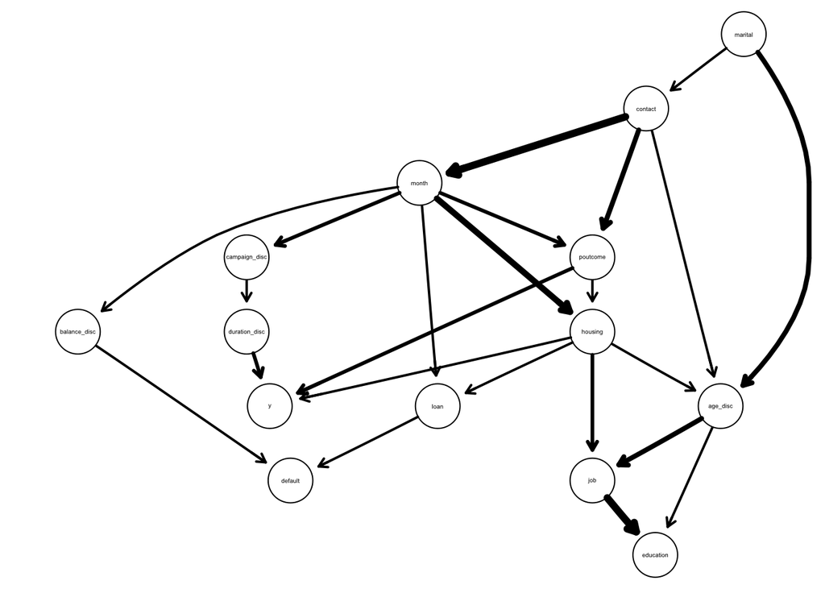

```r
strength.plot(net.bic.1, strength = strength.bic.1)
```

El AIC nos da un modelo demasiado complejo, con 36 arcos, mientras que el BIC nos da algo más aceptable, con 23 arcos. Con BIC nos parece que el modelo queda mucho más interpretable, así que lo utilizaremos de aquí en adelante. Agregamos a la *blacklist* tres elementos más: `housing --> job` porque tiene más sentido pensar en la relación al revés (nos parece más lógico que el trabajo determine si tiene una hipoteca); `job --> education`, por la misma razón que el anterior y finalmente `poutcome --> housing` porque salía de ambos lados en el resultado, pero la otra versión (tener hipoteca afecta si acepta o no un plan de inversión) tiene más sentido. A continuación mostramos el modelo aprendido con estas nuevas restricciones

```r
blk.2 <- expand.grid(from=c('y'), to=names(mkt_train_disc)) %>%
  rbind(data.frame(from=c('housing', 'job', 'poutcome'),
                   to=c('job', 'education', 'housing')))
net.bic.2 <- hc(mkt_train_disc,
                score = 'bic', blacklist = blk.2)
nrow(net.bic.2$arcs) # Numero de arcos del modelo
```

```
## [1] 24
```

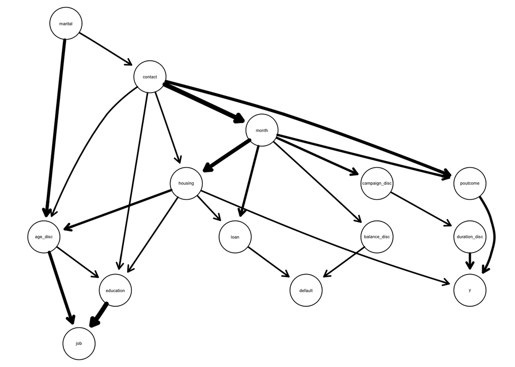

```r
strength.bic.2 <- arc.strength(net.bic.2, mkt_train_disc)
strength.plot(net.bic.2, strength = strength.bic.2)
```

# 2. Aprender Estructura

El siguiente paso ya que tenemos una red es usar bootstrap para encontrar los arcos más fuertes y robustos a la variabilidad. Decidimos usar 500 muestras, aunque en realidad probablemente con unas 50 ya nos salga un buen resultado (lo intentamos con 50 en la etapa de pruebas).

```r
boot.bic.2 <- boot.strength(mkt_train_disc, R = 500, algorithm = 'hc',
                            algorithm.args = list(score='bic', blacklist = blk.2))
```

Ahora mostramos los 10 arcos con más fuerza según bootstrap:

```r
boot.bic.2 %>%
  arrange(desc(strength), desc(direction)) %>%
  head(10)
```

```
##             from           to strength direction
## 1  duration_disc            y        1     1.000
## 2        marital     age_disc        1     0.990
## 3       age_disc          job        1     0.974
## 4       age_disc    education        1     0.974
## 5   balance_disc      default        1     0.926
## 6        housing     age_disc        1     0.902
## 7        contact        month        1     0.833
## 8        contact     poutcome        1     0.833
## 9          month balance_disc        1     0.831
## 10       housing        month        1     0.812
```

Y finalmente graficamos la red final con sus fuerzas de bootstrap. Usamos un umbral de 0.8 porque es bastante alto y da el mismo resultado que 0.9. Después de probar con varios números, nos pareció que 0.8 nos daba una red suficiente pero no excesivamente poblada.

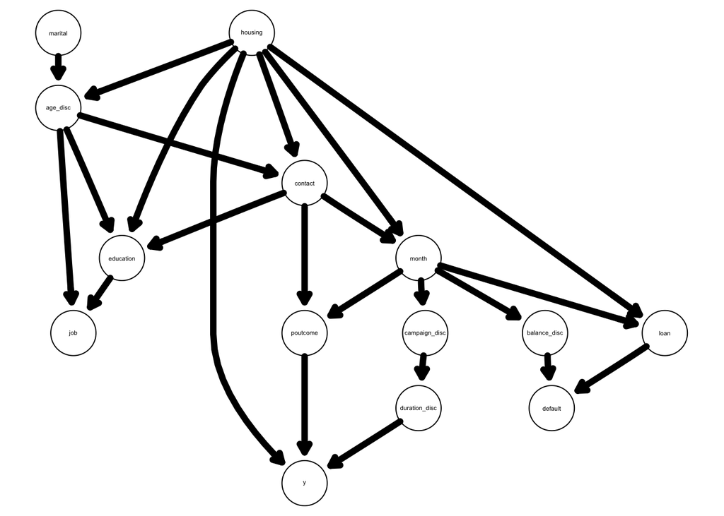

```r
avnet.bic.2 <- averaged.network(strength = boot.bic.2, threshold = 0.8)
strength.bic.2 <- arc.strength(avnet.bic.2, mkt_train_disc)
strength.plot(avnet.bic.2, strength = strength.bic.2)
```

# 3. Modelos Locales

Hay dos tipos de nodos en los que nos interesaría hacer un modelo local. El primero es el de respuesta y el segundo tipo es cualquier nodo con alguna probabilidad no definida. Para ver si hay alguno del segundo tipo, primero ajustamos las probabilidades usando `bn.fit`:

```r
fit.bic.2 <- bn.fit(avnet.bic.2, data = mkt_train_disc, method = 'mle')
```

Y ahora vemos si todos los nodos del modelo ajustado tienen probabilidades numéricas (ie. no NA) que suman uno:

```r
lapply(fit.bic.2, function(x){
  mean(0 <= data.frame(x$prob)$Freq & data.frame(x$prob)$Freq <= 1)
}) %>% data.frame
```

```
##   job marital education default housing loan contact month poutcome y
## 1   1       1         1       1       1    1       1     1        1 1
##   age_disc balance_disc duration_disc campaign_disc
## 1        1            1             1             1
```

Dado que todas las probabilidades están bien definidas, procedemos a ajustar un modelo local al nodo de salida. Elegimos `glmnet` porque nos permite introducir modelos complejos y volverlos más ralos (por la regularización $\ell^1$), además de encoger los coeficientes. Desafortunadamente, después de probar bastantes valores de $\alpha$ y validación cruzada sobre $\lambda$, llegamos a la conclusión de que $\alpha = 0$ (ie. regresión logística con regularización Ridge únicamente) es la mejor elección. También después de experimentar bastante nos dimos cuenta de que no conviene poner todas las interacciones, sino que lo mejor es incluir `poutcome:duration_disc` nada más.

```r
local_train <- mkt_train_disc %>%
  select(y, housing, poutcome, duration_disc) %>%
  group_by(housing, poutcome, duration_disc) %>%
  summarise(y_yes = sum(y == 'yes'), y_no = sum(y == 'no'))
xmat <- model.matrix(~ -1 + housing+poutcome:duration_disc, # Los mejores resultados con x + y:z
                     data=local_train[1:3])
ymat <- as.matrix(local_train[4:5])
fit_local_y <- cv.glmnet(x=xmat, y=ymat, family = 'binomial', alpha=0) # Se ven suaves con Ridge
coefficients(fit_local_y)
```

```
## 23 x 1 sparse Matrix of class "dgCMatrix"
##                                                   1
## (Intercept)                              2.29687819
## housingno                               -0.34559603
## housingyes                               0.34555412
## poutcomefailure:duration_disc[  0,  91)  0.68801427
## poutcomeother:duration_disc[  0,  91)    0.69499350
## poutcomesuccess:duration_disc[  0,  91) -0.43944331
## poutcomeunknown:duration_disc[  0,  91)  0.87857960
## poutcomefailure:duration_disc[ 91, 148)  0.21950745
## poutcomeother:duration_disc[ 91, 148)    0.13407398
## poutcomesuccess:duration_disc[ 91, 148) -1.35958813
## poutcomeunknown:duration_disc[ 91, 148)  0.64286799
## poutcomefailure:duration_disc[148, 224) -0.04870217
## poutcomeother:duration_disc[148, 224)   -0.27247045
## poutcomesuccess:duration_disc[148, 224) -2.16919293
## poutcomeunknown:duration_disc[148, 224)  0.39774780
## poutcomefailure:duration_disc[224, 371) -0.49396769
## poutcomeother:duration_disc[224, 371)   -0.86205114
## poutcomesuccess:duration_disc[224, 371) -2.66335590
## poutcomeunknown:duration_disc[224, 371)  0.09662438
## poutcomefailure:duration_disc[371,4918] -1.45267222
## poutcomeother:duration_disc[371,4918]   -1.59381152
## poutcomesuccess:duration_disc[371,4918] -2.84139984
## poutcomeunknown:duration_disc[371,4918] -1.23269487
```

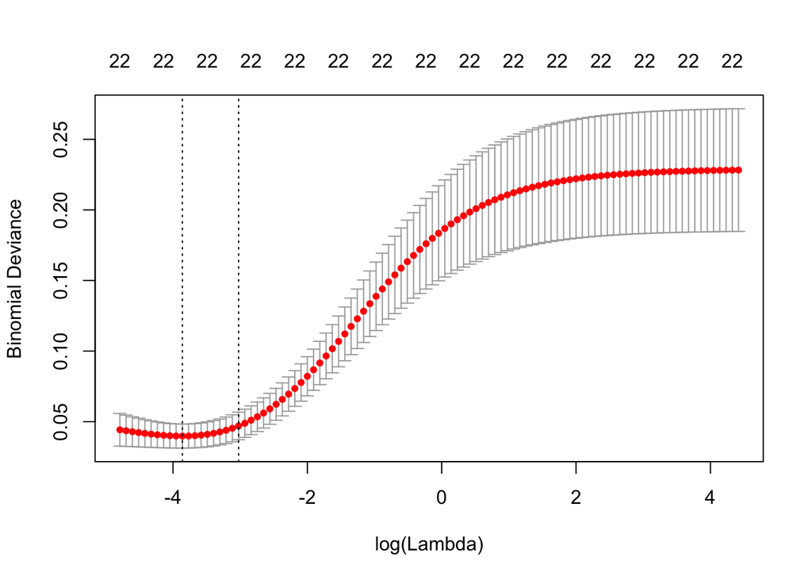

```r
plot(fit_local_y) # La regularizacion no parece aportar mucho en este caso
```

Según la validación cruzada, no ganamos mucho con la regularización, pero veremos cómo nos va en la muestra de prueba más adelante. Por ahora, agregamos las probabilidades obtenidas del ajuste con `glmnet` a una copia del modelo:

```r
# Agregamos las probabilidades a un modelo nuevo
preds_local_y <- as.numeric(predict(fit_local_y, newx=xmat, type='response'))
aux1 <- data.frame(y='no', prob=preds_local_y, local_train) %>%
  rbind(data.frame(y='yes', prob=1-preds_local_y, local_train)) %>%
  mutate(prob_no_mle=y_no/(y_yes+y_no))
head(aux1)
```

```
##    y      prob housing poutcome duration_disc y_yes y_no prob_no_mle
## 1 no 0.9333482      no  failure    [  0,  91)     4  147   0.9735099
## 2 no 0.8975956      no  failure    [ 91, 148)    22  188   0.8952381
## 3 no 0.8701833      no  failure    [148, 224)    41  146   0.7807487
## 4 no 0.8111216      no  failure    [224, 371)    68  161   0.7030568
## 5 no 0.6221326      no  failure    [371,4918]    93   89   0.4890110
## 6 no 0.9337811      no    other    [  0,  91)     1   55   0.9821429
```

```r
tab_local_y <- xtabs(prob~ y + housing + poutcome + duration_disc, data = aux1)
fit.bic.2.reg <- fit.bic.2
fit.bic.2.reg$y <- tab_local_y
```

Ahora mostramos las gráficas de las probabilidades ajustadas por MLE contra las de `glmnet`:

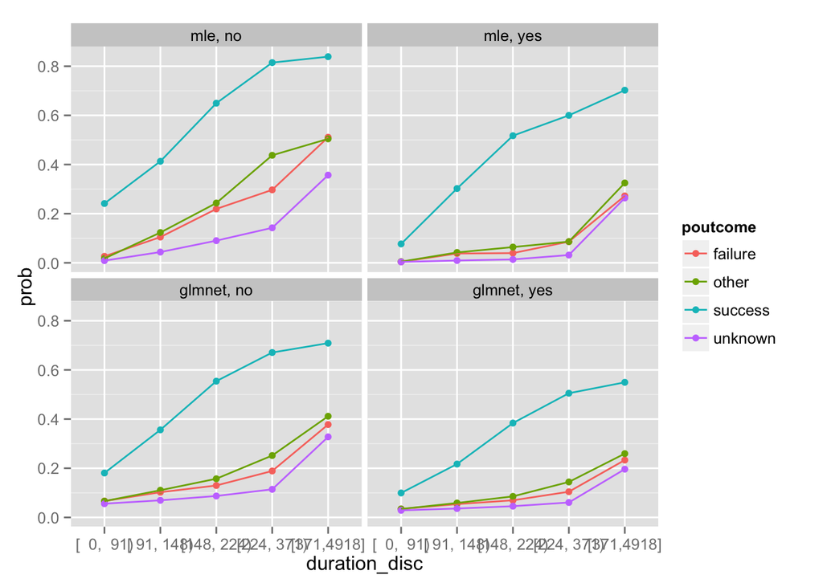

```r
aux <- data.frame(fit.bic.2$y$prob) %>%
  cbind(method = 'mle') %>%
  rbind(data.frame(fit.bic.2.reg$y$prob) %>%
  cbind(method = 'glmnet')) %>%
  rename(prob=Freq) %>%
  filter(y == 'yes')
ggplot(aux, aes(x=duration_disc, y=prob)) +
  geom_point(aes(color=poutcome)) +
  geom_line(aes(group=poutcome, color=poutcome)) +
  facet_wrap(method ~ housing)
```

Si comparamos directamente las probabilidades vemos claramente que están muy correlacionadas, así que no esperaríamos grandes cambios entre unas y otras:

```r
df_preds <- data.frame(fit.bic.2$y$prob) %>% rename(prob_mle=Freq)
aux2 <- data.frame(fit.bic.2.reg$y$prob) %>% rename(prob_glmnet=Freq)
df_preds <- left_join(df_preds, aux2)
```

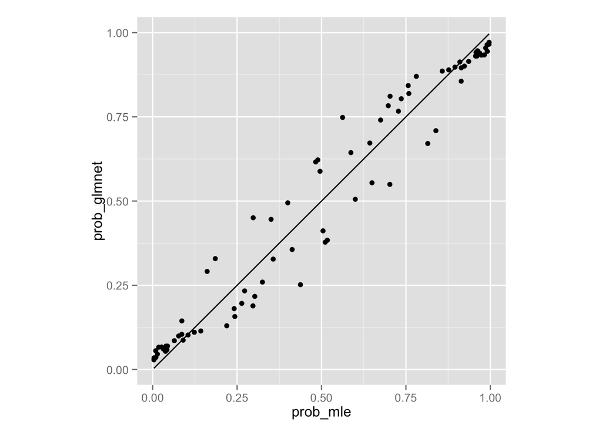

```r
qplot(prob_mle, prob_glmnet, data=df_preds) + geom_line(aes(prob_mle, prob_mle)) + coord_equal()
```

Ahora sí veamos cómo se desempeñan en la base de prueba. Cabe mencionar que en este caso la clase de 1 es `y == 'no'`, así que la sensibilidad es con respecto a esta clase, etc. Los puntos rojos corresponden a modelos con puntos de corte que ofrecen un buen balance entre sensibilidad y especificidad:

```r
mkt_test_pred <- mkt_test %>%
  left_join(df_preds)
```

```r
roc.mle <- roc(mkt_test_pred$y, mkt_test_pred$prob_mle)
roc.glmnet <- roc(mkt_test_pred$y, mkt_test_pred$prob_glmnet)
auc.mle <- auc(roc.mle)
auc.glmnet <- auc(roc.glmnet)
plot(roc.mle)
```

```
##
## Call:
## roc.default(response = mkt_test_pred$y, predictor = mkt_test_pred$prob_mle)
##
## Data: mkt_test_pred$prob_mle in 9459 controls (mkt_test_pred$y no) > 1231 cases (mkt_test_pred$y yes).
## Area under the curve: 0.976
```

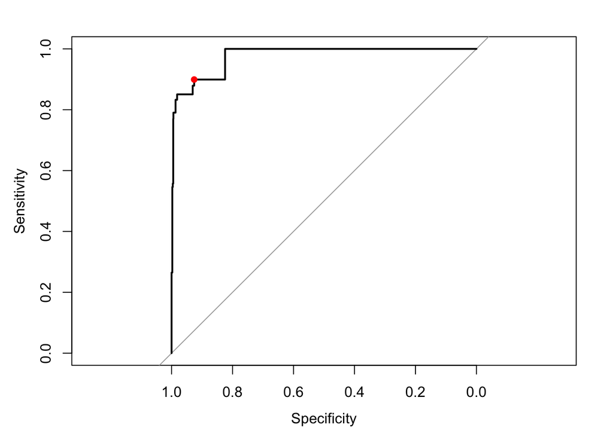

```r
points(roc.mle$specificities[30], roc.mle$sensitivities[30], col='red', pch=16)
```

```r
plot(roc.glmnet)
```

```
##
## Call:
## roc.default(response = mkt_test_pred$y, predictor = mkt_test_pred$prob_glmnet)
##
## Data: mkt_test_pred$prob_glmnet in 9459 controls (mkt_test_pred$y no) > 1231 cases (mkt_test_pred$y yes).
## Area under the curve: 0.9957
```

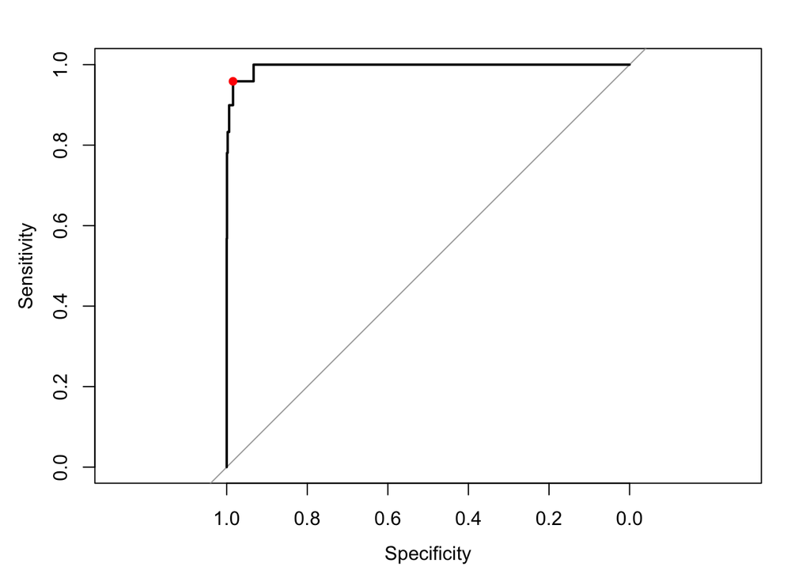

```r
points(roc.glmnet$specificities[33], roc.glmnet$sensitivities[33], col='red', pch=16)
```

Como vemos en la base de prueba ambos modelos tuvieron un desempeño excelente, pero el modelo regularizado ganó con un AUC de 0.9956511 sobre un AUC de 0.976006 de MLE. En realidad el error de predicción no es la mejor medida de desempeño que podemos dar, puesto que depende del punto de corte de ambos modelos y de la pérdida asociada a clasificar bien o mal un caso positivo o negativo. Sin embargo, a continuación mostramos el error de predicción de cada modelo usando sus respectivos puntos rojos como puntos de corte:

```r
mkt_test_pred$pred_test_mle <- (mkt_test_pred$prob_mle < roc.mle$thresholds[30]) # TRUE = 'yes'
mkt_test_pred$pred_test_mle <- ifelse(mkt_test_pred$pred_test_mle, 'yes', 'no')
mkt_test_pred$pred_test_glmnet <- (mkt_test_pred$prob_glmnet < roc.glmnet$thresholds[33]) # TRUE = 'yes'
mkt_test_pred$pred_test_glmnet <- ifelse(mkt_test_pred$pred_test_glmnet, 'yes', 'no')
# Error de prediccion de MLE
1 - sum(mkt_test_pred$pred_test_mle == mkt_test_pred$y) / nrow(mkt_test_pred)
```

```
## [1] 0.07717493
```

```r
# Error de prediccion de glmnet
1 - sum(mkt_test_pred$pred_test_glmnet == mkt_test_pred$y) / nrow(mkt_test_pred)
```

```
## [1] 0.01861553
```

Como vemos, el modelo regularizado da un error bastante menor al de máxima verosimilitud.

# 4. Queries de probabilidad condicional

Elegimos hacer los queries de probabilidad condicional en `gRain` para hacer lo más posible en R. Como el mejor modelo fue el regularizado, haremos los queries con él en lugar del de máxima verosimilitud. Primero compilamos el modelo de `bnlearn` a un objeto de `gRain` y luego hacemos lo queries. Cabe mencionar que no sólo mostramos *P(A = a | B = b)* para un valor de *a*, sino de una vez para todo valor de *a*.

```r
comp_mkt <- compile(as.grain(fit.bic.2.reg))
```

### 4.1 Query 1

**P(Y = 1)**

```r
query1 <- querygrain(comp_mkt)
query1$y
```

```
## y
##        no       yes
## 0.8846331 0.1153669
```

### 4.2 Query 2

**P(Y = 1 | JOB = unemployed, MARITAL = single, EDUCATION = primary)**

```r
query2 <- querygrain(setEvidence(comp_mkt,
                                 nodes=c('job','marital','education'),
                                 states=c('unemployed','single','primary')))
query2$y
```

```
## y
##        no       yes
## 0.8934789 0.1065211
```

### 4.3 Query 3

**P(JOB = admin. | MARITAL = married, EDUCATION = primary, BALANCE = 1000)**

En este caso, como se pide $BALANCE = 1000$, pero tuvimos que discretizar esa variable, en vez ponemos $BALANCE = [696, 1843)$, que es la catagoría que contiene a 1000.

```r
query3 <- querygrain(setEvidence(comp_mkt,
                                 nodes=c('marital','education', 'balance_disc'),
                                 states=c('married','primary','[  696,  1843)')))
query3$job
```

```
## job
##        admin.   blue-collar  entrepreneur     housemaid    management
##   0.029827730   0.532911315   0.024764836   0.096761816   0.045123036
##       retired self-employed      services       student    technician
##   0.128578220   0.019974659   0.050262983   0.003782899   0.023945228
##    unemployed       unknown
##   0.036014115   0.008053161
```

# 5. MAP - Maximum a Posteriori

En este ejercicio compararemos los resultados de aplicar MAP a cada una de las variables implicadas individualmente vs. aplicarlo globalmente. En este ejemplo supondremos que tenemos la siguiente evidencia:

*e = {AGE = 20, MARITAL = married, EDUCATION = secondary, DEFAULT = no, BALANCE = 1000, MONTH = may, CAMPAIGN = 1}*

Primero veamos los resultados de aplicar MAP por variable. Para ello, en SAMIAM ponemos la evidencia y simplemente vemos qué clase es la moda en cada nodo que no está en *e*:

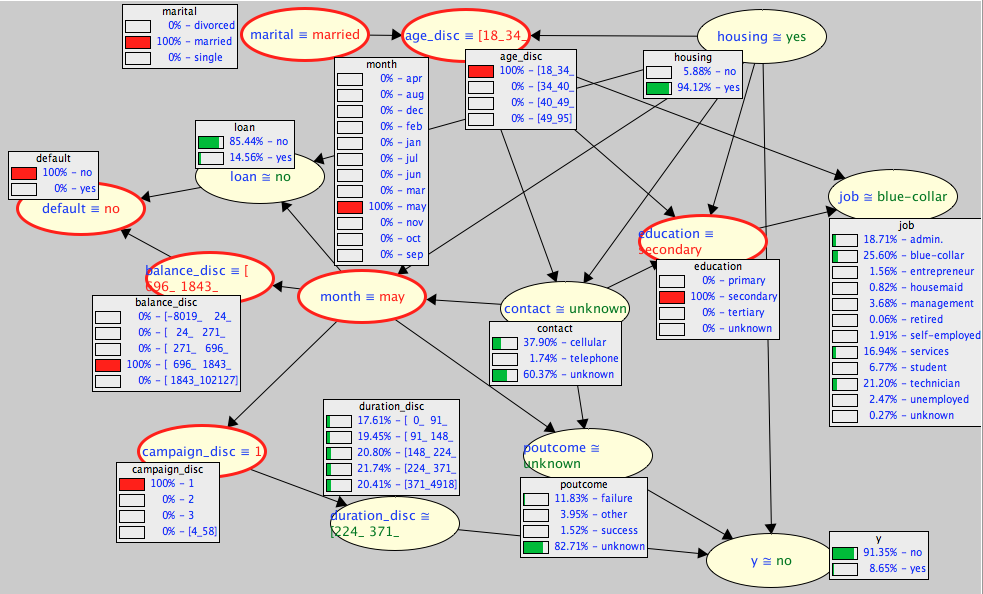

De donde vemos que las máximas probabilidades posteriores son:

- contact = unknown (60.37%)
- duration_disc = [224,371) (21.74%)
- housing = yes (94.12%),
- job = blue-collar (25.60%)
- loan = no (85.44%)
- poutcome = unknown (82.71%)
- y = no (91.35%)

Y ahora veamos qué pasa con MAP global:

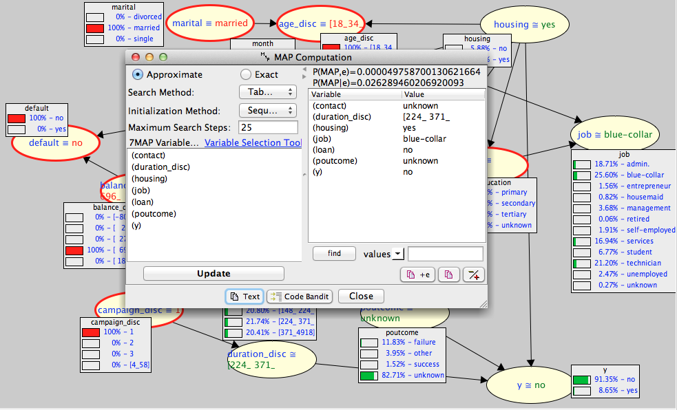

Como vemos, en este caso el resultado es el mismo. Sin embargo, esto no tiene por qué ser cierto en general. Los únicos casos en donde hay garantía de que suceda es en lo que las variables $Y = V \backslash E$ son independientes dado $E$. Esto se debe a que en ese caso, $P(Y = y | E = e) = \prod_i P(Y_i = y_i | E = e)$ y entonces minimizar el producto es equivalente a minimizar los factores por separado, puesto que $P(Y_i = y_i | E = e)$ no depende de ninguna $Y_j$ con $j \neq i$.